# Лабораторная Работа №14

Модели обработки заказов

Козлов В.П.

Российский университет дружбы народов им. Патриса Лумумбы, Москва, Россия

## Докладчик

- Козлов Всеволод Павлович
- НФИбд-02-22
- Российский университет дружбы народов
- [1132226428@pfur.ru]

# Выполнение лабораторной работы

## Цель работы

Реализовать модели обработки заказов и провести анализ результатов.

## Задание

Реализовать с помощью gpss:

- модель оформления заказов клиентов одним оператором;
- построение гистограммы распределения заявок в очереди;
- модель обслуживания двух типов заказов от клиентов в интернет-магазине;
- модель оформления заказов несколькими операторами.

## Модель оформления заказов клиентов одним оператором

Порядок блоков в модели соответствует порядку фаз обработки заказа в реальной системе:

1. клиент оставляет заявку на заказ в интернет-магазине;
2. если необходимо, заявка от клиента ожидает в очереди освобождения оператора для оформления заказа;
3. заявка от клиента принимается оператором для оформления заказа;
4. оператор оформляет заказ;
5. клиент получает подтверждение об оформлении заказа (покидает систему).

## Модель оформления заказов клиентов одним оператором

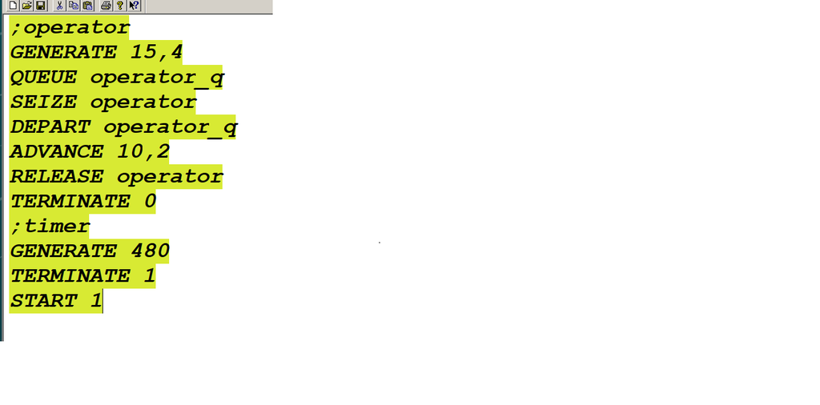

Модель оформления заказов клиентов одним оператором

## Отчёт по модели оформления заказов в интернет-магазине

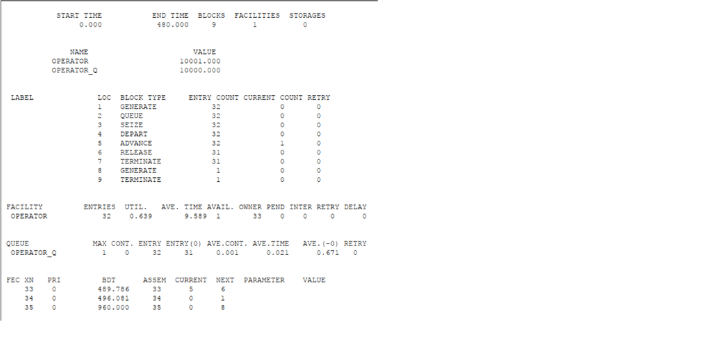

Отчёт по модели оформления заказов в интернет-магазине

## Результаты работы модели

Результаты работы модели:

- модельное время в начале моделирования: `START TIME`=0.0;
- абсолютное время или момент, когда счетчик завершений принял значение 0: `END TIME`=480.0;
- количество блоков, использованных в текущей модели, к моменту завершения моделирования: `BLOCKS`=9;
- количество одноканальных устройств, использованных в модели к моменту завершения моделирования: `FACILITIES`=1;
- количество многоканальных устройств, использованных в текущей модели к моменту завершения моделирования: `STORAGES`=0. Имена, используемые в программе модели: `operator`, `operator_q`.

## Упражнене. Изменение интервалов поступления заказов и время оформления клиентов

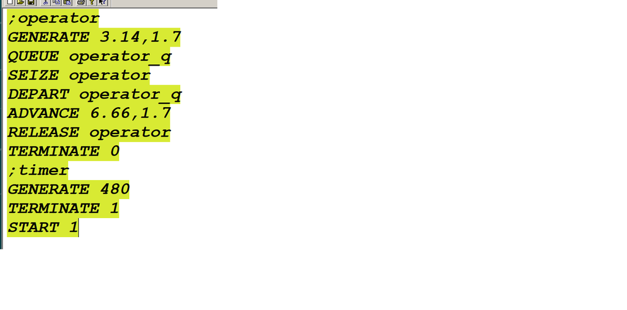

Модель оформления заказов клиентов одним оператором с измененными интервалами заказов и времени оформления клиентов

## Отчёт по модели оформления заказов в интернет-магазине с измененными интервалами заказов и времени оформления клиентов

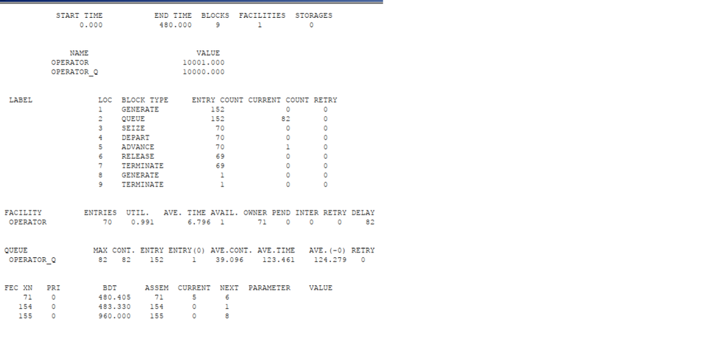

Отчёт по модели оформления заказов в интернет-магазине с измененными интервалами заказов и времени оформления клиентов

## Результаты работы модели

Результаты работы модели:

- модельное время в начале моделирования: `START TIME`=0.0;
- абсолютное время или момент, когда счетчик завершений принял значение 0: `END TIME`=480.0;
- количество блоков, использованных в текущей модели, к моменту завершения моделирования: `BLOCKS`=9;
- количество одноканальных устройств, использованных в модели к моменту завершения моделирования: `FACILITIES`=1;
- количество многоканальных устройств, использованных в текущей модели к моменту завершения моделирования: `STORAGES`=0.

## Построение гистограммы распределения заявок в очереди

Требуется построить гистограмму распределения заявок, ожидающих обработки в очереди в примере из предыдущего упражнения. Для построения гистограммы необходимо сформировать таблицу значений заявок в очереди, записываемых в неё с определённой частотой.

Команда описания такой таблицы `QTABLE` имеет следующий формат: `Name QTABLE A,B,C,D` Здесь `Name` – метка, определяющая имя таблицы. Далее должны быть заданы операнды: `А` задается элемент данных, чьё частотное распределение будет заноситься в таблицу (может быть именем, выражением в скобках или системным числовым атрибутом (СЧА)); `B` задается верхний предел первого частотного интервала; `С` задает ширину частотного интервала — разницу между верхней и нижней границей каждого частотного класса; `D` задаёт число частотных интервалов.

## Построение гистограммы распределения заявок в очереди

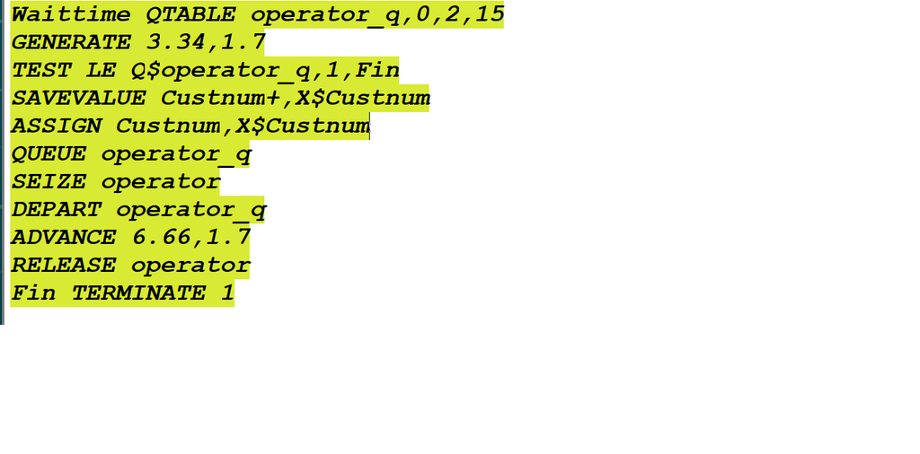

Построение гистограммы распределения заявок в очереди

## Отчёт по модели оформления заказов в интернет-магазине при построении гистограммы распределения заявок в очереди

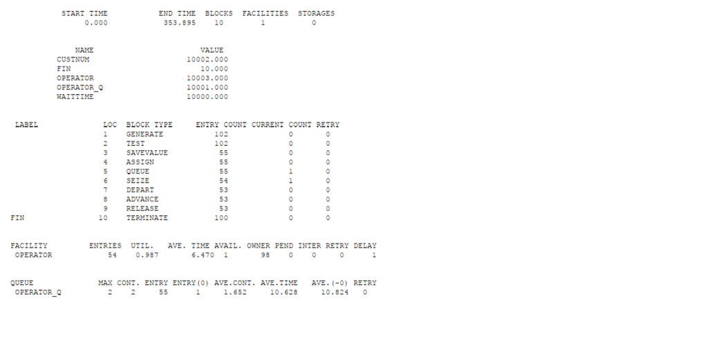

Отчёт по модели оформления заказов в интернет-магазине при построении гистограммы распределения заявок в очереди

## Результаты работы модели

Результаты работы модели:

- модельное время в начале моделирования: `START TIME`=0.0;
- абсолютное время или момент, когда счетчик завершений принял значение 0: `END TIME`=353.895;
- количество блоков, использованных в текущей модели, к моменту завершения моделирования: `BLOCKS`=10;
- количество одноканальных устройств, использованных в модели к моменту завершения моделирования: `FACILITIES`=1;
- количество многоканальных устройств, использованных в текущей модели к моменту завершения моделирования: `STORAGES`=0.

## Построение гистограммы

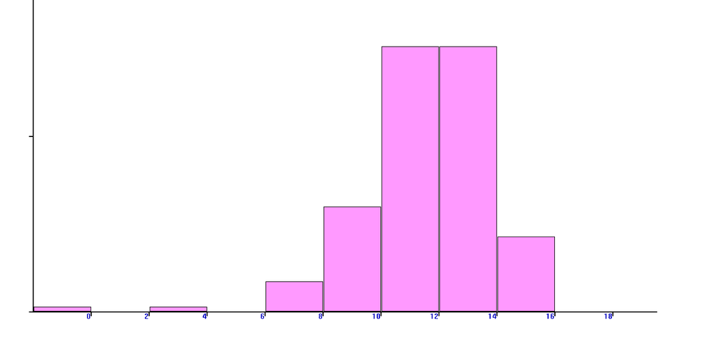

Гистограмма распределения заявок в очереди

## Модель обслуживания двух типов заказов от клиентов в интернет-магазине

Необходимо реализовать отличие в оформлении обычных заказов и заказов с дополнительным пакетом услуг. Такую систему можно промоделировать с помощью двух сегментов. Один из них моделирует оформление обычных заказов, а второй – заказов с дополнительным пакетом услуг. В каждом из сегментов пара `QUEUE–DEPART` должна описывать одну и ту же очередь, а пара блоков `SEIZE–RELEASE` должна описывать в каждом из двух сегментов одно и то же устройство и моделировать работу оператора.

## Модель обслуживания двух типов заказов от клиентов в интернет-магазине

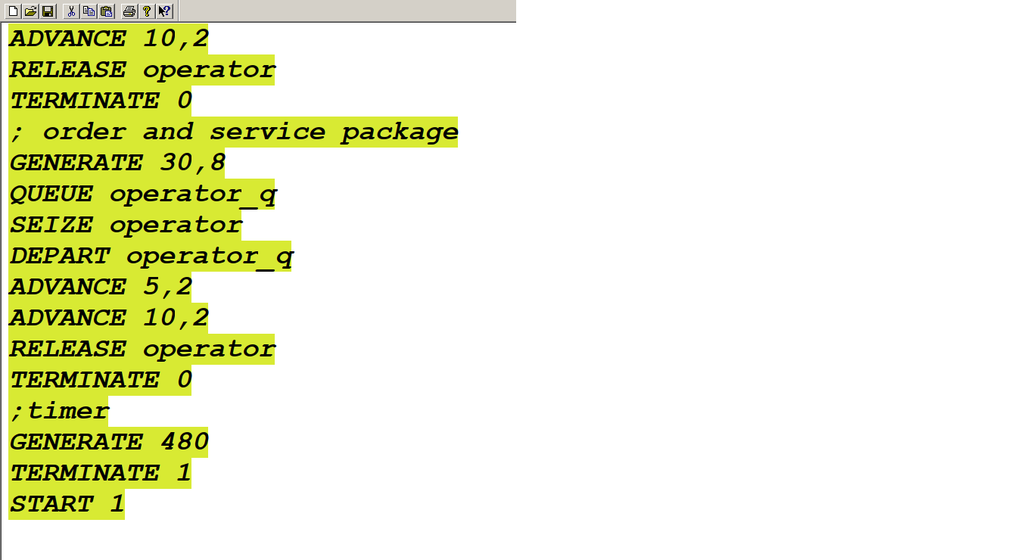

Модель обслуживания двух типов заказов от клиентов в интернет-магазине

## Отчёт по модели оформления заказов двух типов

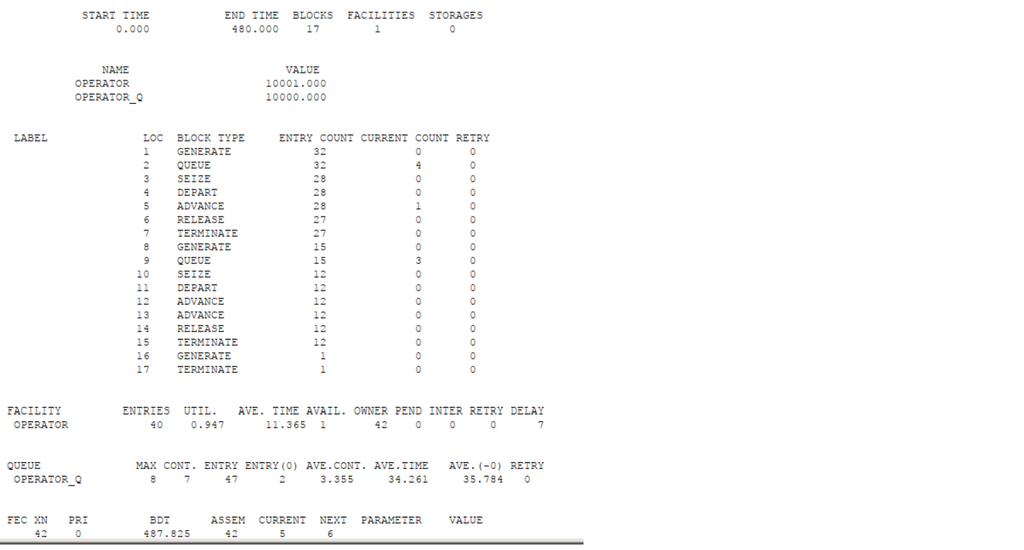

Отчёт по модели оформления заказов двух типов

## Результаты работы модели

Результаты работы модели:

- модельное время в начале моделирования: `START TIME`=0.0;
- абсолютное время или момент, когда счетчик завершений принял значение 0: `END TIME`=480.0;
- количество блоков, использованных в текущей модели, к моменту завершения моделирования: `BLOCKS`=17;
- количество одноканальных устройств, использованных в модели к моменту завершения моделирования: `FACILITIES`=1;
- количество многоканальных устройств, использованных в текущей модели к моменту завершения моделирования: `STORAGES`=0.

## Упражнение

Скорректируем модель так, чтобы учитывалось условие, что число заказов с дополнительным пакетом услуг составляет 30% от общего числа заказов.

Будем использовать один блок `order`, а разделим типы заявок с помощью переходов оператором `TRANSFER`. Каждый заказ обрабатывается $10 ± 2$ минуты, после этого зададим оператор `TRANSFER`, в котором укажем, что с вероятностью 0.7 происходит обработка заявки (переход к блоку `noextra` `RELEASE` operator), а с вероятностью 0.3 дополнительно заказ обрабатывается еще $5 ± 2$ минуты (переход к блоку `extra` `ADVANCE` 5,2) и только после этого является обработанным

## Модель обслуживания двух типов заказов с условием, что число заказов с дополнительным пакетом услуг составляет 30% от общего числа заказов

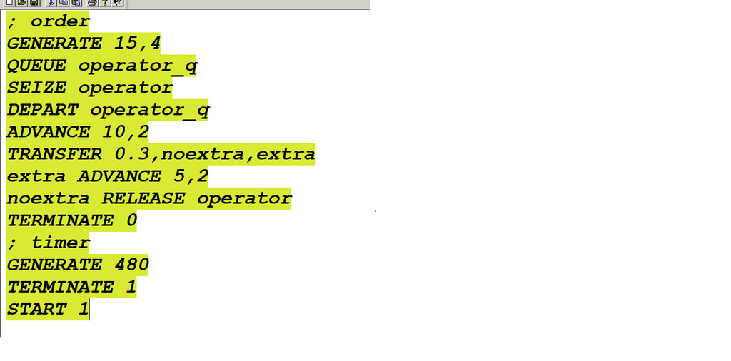

Модель обслуживания двух типов заказов с условием, что число заказов с дополнительным пакетом услуг составляет 30% от общего числа заказов

## Отчёт по модели оформления заказов двух типов заказов

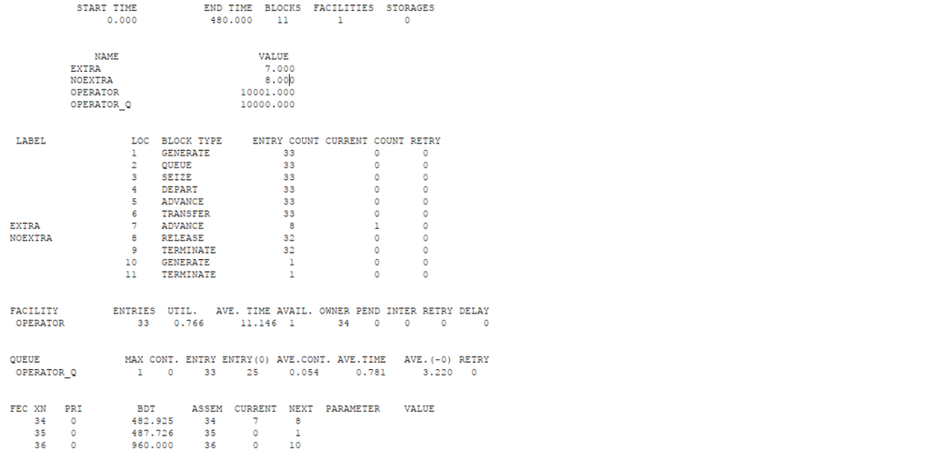

Отчёт по модели оформления заказов двух типов заказов

## Результаты работы модели

Результаты работы модели:

- модельное время в начале моделирования: `START TIME`=0.0;
- абсолютное время или момент, когда счетчик завершений принял значение 0: `END TIME`=480.0;
- количество блоков, использованных в текущей модели, к моменту завершения моделирования: `BLOCKS`=11;
- количество одноканальных устройств, использованных в модели к моменту завершения моделирования: `FACILITIES`=1;
- количество многоканальных устройств, использованных в текущей модели к моменту завершения моделирования: `STORAGES`=0.

## Модель оформления заказов несколькими операторами

В интернет-магазине заказы принимают 4 оператора. Интервалы поступления заказов распределены равномерно с интервалом $5 ± 2$ мин. Время оформления заказа каждым оператором также распределено равномерно на интервале $10 ± 2$ мин. обработка поступивших заказов происходит в порядке очереди (FIFO). Требуется определить характеристики очереди заявок на оформление заказов при условии, что заявка может обрабатываться одним из 4-х операторов в течение восьмичасового рабочего дня

С помощью строки `operator STORAGE 4` указываем, что у нас 4 оператора, затем к обычной процедуре генерации и обработки заявки добавляется, что заявку обрабатывает один оператор `operator,1`, сегмент моделирования времени остается без изменений

## Модель оформления заказов несколькими операторами

[figure not shown]

Модель оформления заказов несколькими операторами

## Отчет по модели оформления заказов несколькими операторами

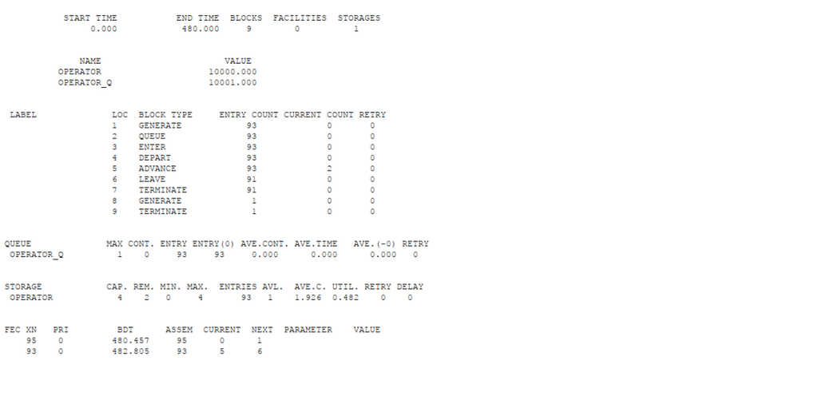

Отчет по модели оформления заказов несколькими операторами

## Упражнение

Изменим модель: требуется учесть в ней возможные отказы клиентов от заказа – когда при подаче заявки на заказ клиент видит в очереди более двух других заявок, он отказывается от подачи заявки, то есть отказывается от обслуживания (используем блок `TEST` и стандартный числовой атрибут Qj текущей длины очереди j).

Добавим строчку `TEST LE Q$operator_q,2`, которая проверяет больше ли в очереди клиентов, чем два, если нет – клиент поступает на обработку, иначе уходит. Также в ранее проанализированном отчете видно, что клиентов в очереди не было больше 2, поэтому увеличим время обработки заказов до $30 ± 2$ мин., чтобы проверить результаты изменений модели

## Модель оформления заказов несколькими операторами с учетом отказов клиентов

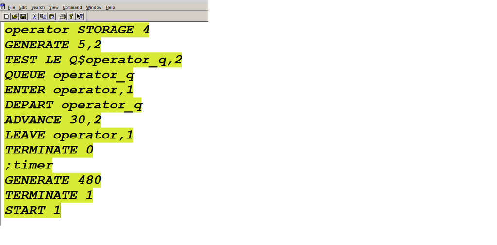

Модель оформления заказов несколькими операторами с учетом отказов клиентов

## Отчет по модели оформления заказов несколькими операторами с учетом отказов клиентов

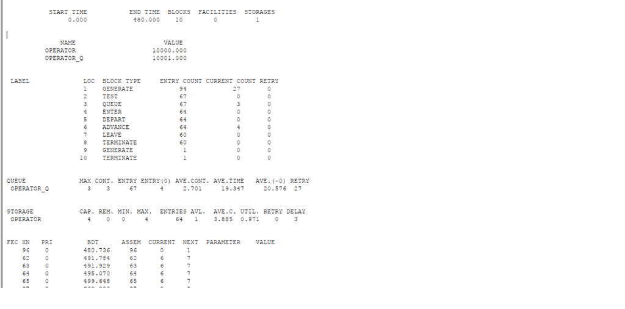

Отчет по модели оформления заказов несколькими операторами с учетом отказов клиентов

## Выводы

В результате была реализована с помощью gpss:

- модель оформления заказов клиентов одним оператором;
- построение гистограммы распределения заявок в очереди;
- модель обслуживания двух типов заказов от клиентов в интернет-магазине;
- модель оформления заказов несколькими операторами.